# R Notebook

```r
library(readr)
library(dplyr)
library(ggplot2)
library(ez)
library(tidyr)
```

# Subject Exclusions

We are removing subjects who do not have at least 80% good segments.

```r
subject.segment.log <- read_csv('data/tidy/eeg-segment-count.csv')
good.subjects <- subject.segment.log %>%
  filter(P >= 0.8) %>%
  pull(Subject)
```

# Behavioral Data

Loading in the data and filtering to only good subjects.

```r
all.behavioral.data <- read_csv('data/tidy/behavioral-data-tidy.csv', progress = FALSE) %>%
  filter(participant_id %in% good.subjects)
```

Graph

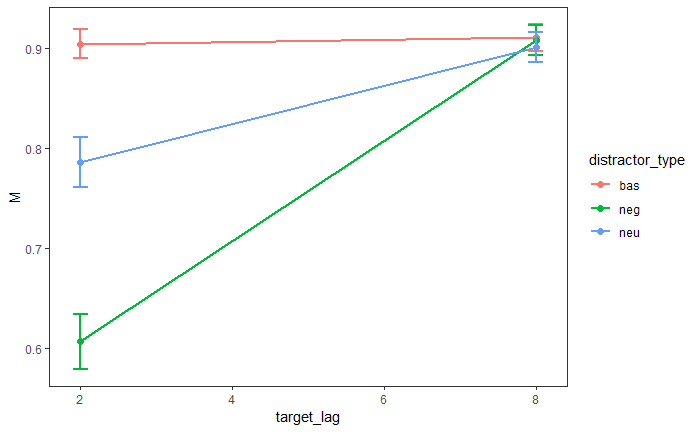

```r
subject.level <- all.behavioral.data %>%
  filter(phase == 'test', target_lag %in% c(2,8)) %>%
  mutate(correct = as.numeric((correct == 'true'))) %>%
  group_by(participant_id, distractor_type, target_lag) %>%
  summarize(accuracy = mean(correct))
summary.data <- subject.level %>%
  group_by(distractor_type, target_lag) %>%
  summarize(M=mean(accuracy), SD=sd(accuracy), SE=sd(accuracy)/sqrt(n()))
ggplot(summary.data, aes(x=target_lag, y=M, color=distractor_type, group=distractor_type))+
  geom_line(size=1)+
  geom_point(size=2)+
  geom_errorbar(aes(ymin=M-SE, ymax=M+SE), size=1,width=0.2)+
  theme_bw()+
  theme(panel.grid=element_blank())
```

ANOVA

```r
behavioral.anova <- ezANOVA(subject.level, dv=accuracy, wid=participant_id, within=c(target_lag, distractor_type))
behavioral.anova$ANOVA
```

|  | Effect | DFn | DFd | F | p | p<.05 | ges |
| --- | --- | --- | --- | --- | --- | --- | --- |
| 1 | target_lag | 1 | 21 | 129.87428 | 1.875189e-10 | * | 0.6752405 |
| 2 | distractor_type | 2 | 42 | 100.43015 | 9.902572e-17 | * | 0.6136741 |
| 3 | target_lag:distractor_type | 2 | 42 | 98.61875 | 1.357753e-16 | * | 0.6089889 |

# EEG Data

We start by loading in the tidy EEG data. See the `generate-tidy-eeg-data.R` file for the pre-processing steps that produced this file.

```r
# use progress=FALSE because progress bar seems to slow down read_csv in R notebooks.
eeg.data <- read_csv('data/tidy/eeg-data-tidy.csv', progress= FALSE) %>%
  filter(subject %in% good.subjects)
```

## N2

### Distractor Pictures

Kennedy et al. start by isolating the N2 in response to the distractor images by subtracting the lag 8 baseline from the negative and neutral lag 8 conditions.

We calculate the difference wave at each electrode for each subject in each condition.

```r
n2.distractor.data <- eeg.data %>%
  filter(lag.condition == "Lag8", electrode %in% c(64,68,69,89,94,95)) %>%
  mutate(hemisphere = if_else(electrode > 70, "right","left")) %>%
  select(-lag.condition)
n2.distractor.baseline.data <- n2.distractor.data %>%
  filter(distractor.condition == "Baseline") %>%
  mutate(baseline.voltage = voltage) %>%
  select(-voltage, -distractor.condition)
n2.distractor.difference.waves <- n2.distractor.data %>%
  left_join(n2.distractor.baseline.data, by=c("subject", "t", "electrode", "hemisphere")) %>%
  mutate(difference.wave = voltage - baseline.voltage) %>%
  select(-voltage, -baseline.voltage) %>%
  filter(distractor.condition != "Baseline")
```

A two-factor ANOVA (hemisphere x distractor type) in the time window 185-275ms, on peak negative amplitude. (First average over hemisphere, then find peak)

```r
n2.distractor.anova.data <- n2.distractor.difference.waves %>%
  filter(t %in% 185:275) %>%
  group_by(subject, hemisphere, distractor.condition, t) %>%
  summarize(M = mean(difference.wave)) %>%
  group_by(subject, hemisphere, distractor.condition) %>%
  summarize(peak = min(M))
n2.distractor.anova <- ezANOVA(n2.distractor.anova.data, wid=subject, dv=peak, within=c(hemisphere, distractor.condition))
n2.distractor.anova$ANOVA
```

|  | Effect | DFn | DFd | F | p | p<.05 | ges |
| --- | --- | --- | --- | --- | --- | --- | --- |
| 2 | hemisphere | 1 | 21 | 3.0040253 | 0.09771856 |  | 0.0157692389 |
| 3 | distractor.condition | 1 | 21 | 1.2709943 | 0.27229744 |  | 0.0093310309 |
| 4 | hemisphere:distractor.condition | 1 | 21 | 0.8472484 | 0.36778547 |  | 0.0008344005 |

Follow up t-tests.

First we have to collapse over hemisphere. Note that we take the MIN rather than average when collapsing over hemisphere since we are looking for peak negative amplitude. (Code is shown here to provide a model for performing t-tests.

```r
n2.distractor.t.test.data <- n2.distractor.anova.data %>%
  group_by(subject, distractor.condition) %>%
  summarize(peak = min(peak))
```

Is negative less than neutral?

**Note: In an earlier version of this Notebook I neglected to make this a paired t-test!**

```r
t.test(peak ~ distractor.condition, data=n2.distractor.t.test.data, alternative="less", paired=TRUE)
```

```
    Paired t-test

data:  peak by distractor.condition
t = -1.161, df = 21, p-value = 0.1293
alternative hypothesis: true difference in means is less than 0
95 percent confidence interval:
      -Inf 0.1379766
sample estimates:
mean of the differences
             -0.2861961
```

Follow up one-sample, one-tailed t-tests to see if N2s are less than 0.

Negative condition:

```r
# the pull() command extracts the column from the data frame.
n2.distractor.t.test.data %>%
  filter(distractor.condition == "Negative") %>%
  pull(peak) %>%
  t.test(mu=0, alternative="less")
```

```
    One Sample t-test

data:  .
t = -2.8582, df = 21, p-value = 0.004707
alternative hypothesis: true mean is less than 0
95 percent confidence interval:
       -Inf -0.3605607
sample estimates:
 mean of x
-0.9060238
```

Neutral condition:

```r
n2.distractor.t.test.data %>%
  filter(distractor.condition == "Neutral") %>%
  pull(peak) %>%
  t.test(mu=0, alternative="less")
```

```
    One Sample t-test

data:  .
t = -2.0308, df = 21, p-value = 0.02756
alternative hypothesis: true mean is less than 0
95 percent confidence interval:
        -Inf -0.09463463
sample estimates:
 mean of x
-0.6198277
```

Basic plotting of the ERPs. (You should make a better plot than this!) This is analogous to Figure 3.

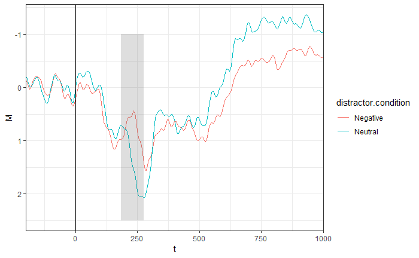

```r
n2.distractor.erp <- n2.distractor.difference.waves %>%
  group_by(distractor.condition, t) %>%
  summarize(M = mean(difference.wave))
ggplot(n2.distractor.erp, aes(x=t, y=M, color=distractor.condition))+
  geom_line()+
  geom_vline(xintercept = 0)+
  scale_y_reverse()+
  scale_x_continuous(limits = c(-200,1000), expand=c(0,0))+
  annotate("rect", xmin=185,xmax=275,ymin=-1,ymax=2.5, alpha=0.2)+
  theme_bw()
```

*Note that it is weird that the average waveforms in the target window are positive, but the t-tests for peak negative amplitude in this window are significantly below 0! Why might that happen, and what does it potentially say about peak negative amplitude as a way of establishing whether there is a significantly below 0 effect?*

### Target Pictures

We need to subtract each lag 8 condition from the corresponding lag 2, which isolates the appearance of the target.

```r
n2.target.data <- eeg.data %>%
  filter(electrode %in% c(64,68,69,89,94,95)) %>%
  mutate(hemisphere = if_else(electrode > 70, "right","left"))
n2.target.difference.waves <- n2.target.data %>%
  spread(lag.condition, voltage) %>%
  mutate(difference.wave = Lag2 - Lag8) %>%
  select(-Lag2, -Lag8)
```

ANOVA on **mean** difference (Kennedy et al. are not clear about whether this should be peak or mean…) in the time window 405-585ms after distractor.

```r
n2.target.anova.data <- n2.target.difference.waves %>%
  filter(t %in% 405:585) %>%
  group_by(subject, hemisphere, distractor.condition) %>%
  summarize(M=mean(difference.wave))
n2.target.anova <- ezANOVA(n2.target.anova.data, wid=subject, dv=M, within=c(hemisphere, distractor.condition))
n2.target.anova$ANOVA
```

|  | Effect | DFn | DFd | F | p | p<.05 | ges |
| --- | --- | --- | --- | --- | --- | --- | --- |
| 2 | hemisphere | 1 | 21 | 0.02319651 | 0.880400976 |  | 5.924205e-05 |
| 3 | distractor.condition | 2 | 42 | 6.62055733 | 0.003167554 | * | 9.767684e-02 |
| 4 | hemisphere:distractor.condition | 2 | 42 | 0.07772913 | 0.925347783 |  | 5.218901e-04 |

Post-hoc tests

```r
n2.target.t.test.data <- n2.target.anova.data %>%
  group_by(subject, distractor.condition) %>%
  summarize(M=mean(M))
```

Baseline vs. Negative. Is Baseline LESS than Negative, one-tailed?

**Note about the direction of the alternative hypothesis for one-tailed tests.** In R you can specify the alternative as `"less"` or `"greater"` for a one-tailed test. Which one you should choose depends on the order of the factor, i.e., is R subtracting Baseline from Negative, or Negative from Baseline. You can find the order of the factor by typing:

```r
levels(factor(n2.target.t.test.data$distractor.condition))
```

```
[1] "Baseline" "Negative" "Neutral"
```

R will subtract levels that appear later in the list FROM levels that appear earlier in the list. So if we want to know if Negative - Baseline is a positive number (i.e., Baseline is less than Negative) then the alternative has to be `"less"` because R will do the subtraction as Baseline - Negative.

```r
t.test(M ~ distractor.condition,
       data = (n2.target.t.test.data %>% filter(distractor.condition != "Neutral")),
       paired = TRUE,
       alternative="less")
```

```
    Paired t-test

data:  M by distractor.condition
t = -3.5947, df = 21, p-value = 0.0008525
alternative hypothesis: true difference in means is less than 0
95 percent confidence interval:
      -Inf -0.516237
sample estimates:
mean of the differences
             -0.9902751
```

Baseline vs. Neutral. Is Baseline LESS than Neural, one tailed?

```r
t.test(M ~ distractor.condition,
       data = (n2.target.t.test.data %>% filter(distractor.condition != "Negative")),
       paired = TRUE,
       alternative="less")
```

```
    Paired t-test

data:  M by distractor.condition
t = -3.7654, df = 21, p-value = 0.0005685
alternative hypothesis: true difference in means is less than 0
95 percent confidence interval:
      -Inf -0.390986
sample estimates:
mean of the differences
             -0.7200393
```

Negative vs. Neutral. Is Neutral LESS than Negative, one tailed?

```r
t.test(M ~ distractor.condition,
       data = (n2.target.t.test.data %>% filter(distractor.condition != "Baseline")),
       paired = TRUE,
       alternative="greater")
```

```
    Paired t-test

data:  M by distractor.condition
t = 0.76434, df = 21, p-value = 0.2266
alternative hypothesis: true difference in means is greater than 0
95 percent confidence interval:
 -0.3381435        Inf
sample estimates:
mean of the differences
              0.2702359
```

Basic plot (Figure 4)

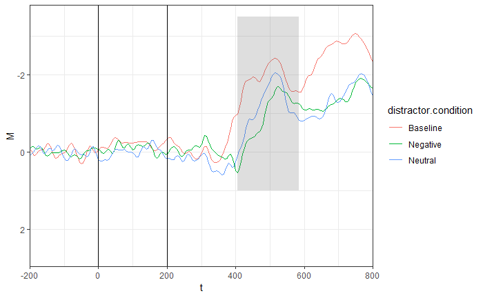

```r
n2.target.plotting.data <- n2.target.difference.waves %>%
  group_by(distractor.condition, t) %>%
  summarize(M=mean(difference.wave))
ggplot(n2.target.plotting.data,  aes(x=t, y=M, color=distractor.condition))+
  geom_line()+
  geom_vline(xintercept=0)+
  geom_vline(xintercept=200)+
  scale_y_reverse()+
  scale_x_continuous(limits = c(-200,800), expand=c(0,0))+
  annotate("rect", xmin=405,xmax=585,ymin=-3.5,ymax=1, alpha=0.2)+
  theme_bw()
```

## P3b

### Target Pictures

Subtract Lag 8 from Lag 2 for each condition. Target electrodes: 54, 55, 79, 78, 61, 62. Time window: 635-995.

```r
p3b.target.data <- eeg.data %>%
  filter(electrode %in% c(54,55,79,78,61,62))
p3b.target.difference.waves <- p3b.target.data %>%
  spread(lag.condition, voltage) %>%
  mutate(difference.wave = Lag2 - Lag8) %>%
  select(-Lag2, -Lag8) %>%
  group_by(subject, t, distractor.condition) %>%
  summarize(M.difference.wave = mean(difference.wave))
```

ANOVA

```r
p3b.target.anova.data <- p3b.target.difference.waves %>%
  filter(t %in% 635:995) %>%
  group_by(subject, distractor.condition) %>%
  summarize(M = mean(M.difference.wave))
p3b.target.anova <- ezANOVA(p3b.target.anova.data, wid=subject, dv=M, within=c(distractor.condition))
p3b.target.anova$ANOVA
```

|  | Effect | DFn | DFd | F | p | p<.05 | ges |
| --- | --- | --- | --- | --- | --- | --- | --- |
| 2 | distractor.condition | 2 | 42 | 4.80854 | 0.01316961 | * | 0.0329214 |

Post-hoc tests

Is Baseline GREATER than Neutral?

```r
t.test(M ~ distractor.condition,
       data = (p3b.target.anova.data %>% filter(distractor.condition != "Negative")),
       paired = TRUE,
       alternative="greater")
```

```
    Paired t-test

data:  M by distractor.condition
t = 2.5738, df = 21, p-value = 0.008851
alternative hypothesis: true difference in means is greater than 0
95 percent confidence interval:
 0.1896923       Inf
sample estimates:
mean of the differences
              0.5723399
```

Is Baseline GREATER than Negative?

```r
t.test(M ~ distractor.condition,
       data = (p3b.target.anova.data %>% filter(distractor.condition != "Neutral")),
       paired = TRUE,
       alternative="greater")
```

```
    Paired t-test

data:  M by distractor.condition
t = 2.5764, df = 21, p-value = 0.008801
alternative hypothesis: true difference in means is greater than 0
95 percent confidence interval:
 0.1406848       Inf
sample estimates:
mean of the differences
              0.4236161
```

Is Neutral GREATER than Negative?

```r
t.test(M ~ distractor.condition,
       data = (p3b.target.anova.data %>% filter(distractor.condition != "Baseline")),
       paired = TRUE,
       alternative="less")
```

```
    Paired t-test

data:  M by distractor.condition
t = 0.81187, df = 21, p-value = 0.787
alternative hypothesis: true difference in means is less than 0
95 percent confidence interval:
      -Inf 0.4639393
sample estimates:
mean of the differences
              0.1487238
```

Plot (Figure 5)

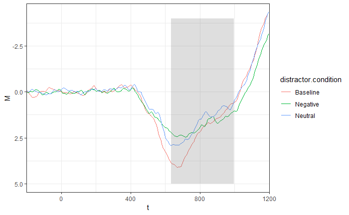

```r
p3b.target.plot.data <- p3b.target.difference.waves %>%
  group_by(t, distractor.condition) %>%
  summarize(M = mean(M.difference.wave))
ggplot(p3b.target.plot.data, aes(x=t,y=M, color=distractor.condition))+
  geom_line()+
  scale_y_reverse()+
  scale_x_continuous(limits = c(-200,1200), expand=c(0,0))+
  annotate("rect", xmin=635,xmax=995,ymin=-4,ymax=5, alpha=0.2)+
  theme_bw()
```

### Distractor Pictures

Subtract Lag 8 Baseline from Lag 8 Neg and Neu. Time window: 400-550ms. Then merge in lag 2 baseline - lag 8 baseline. *Note that this means the baseline condition is looking at something different than the other conditions.*

```r
p3b.distractor.data <- eeg.data %>%
  filter(electrode %in% c(54,55,79,78,61,62)) %>%
  filter(lag.condition == "Lag8") %>%
  select(-lag.condition)
p3b.distractor.baseline <- p3b.distractor.data %>%
  filter(distractor.condition == "Baseline") %>%
  mutate(baseline.voltage = voltage) %>%
  select(-voltage, -distractor.condition)

# need to merge in lag 2 baseline - lag 8 baseline
p3b.distractor.baseline.difference <- eeg.data %>%
  filter(electrode %in% c(54,55,79,78,61,62)) %>%
  filter(distractor.condition == "Baseline") %>%
  spread(lag.condition, voltage) %>%
  mutate(difference.wave = Lag2 - Lag8) %>%
  select(-Lag2, -Lag8)
p3b.distractor.difference.waves <- p3b.distractor.data %>%
  inner_join(p3b.distractor.baseline, by=c("subject", "t", "electrode")) %>%
  filter(distractor.condition != "Baseline") %>%
  mutate(difference.wave = voltage - baseline.voltage) %>%
  select(-baseline.voltage, -voltage) %>%
  rbind(p3b.distractor.baseline.difference)
```

ANOVA

[output not shown]

Post-hoc tests

Is Baseline LESS than Neutral?

[output not shown]

Is Baseline LESS than Negative?

[output not shown]

Is Neutral LESS than Negative?

[output not shown]

Plot (Figure 6)

[figure not shown]

## Posterior Positivity

Remove lag 8 baseline from lag 8 neutral and negative, as in the N2 analysis. But the electrodes are different here: 64, 68, 69, 96, 100, 101. Critical time window: 405-615ms.

```r
pp.data <- eeg.data %>%
  filter(lag.condition == "Lag8", electrode %in% c(64,68,69,96,100,101)) %>%
  mutate(hemisphere = if_else(electrode > 70, "right","left")) %>%
  select(-lag.condition)
pp.baseline.data <- pp.data %>%
  filter(distractor.condition == "Baseline") %>%
  mutate(baseline.voltage = voltage) %>%
  select(-voltage, -distractor.condition)
pp.difference.waves <- pp.data %>%
  left_join(pp.baseline.data, by=c("subject", "t", "electrode", "hemisphere")) %>%
  mutate(difference.wave = voltage - baseline.voltage) %>%
  select(-voltage, -baseline.voltage) %>%
  filter(distractor.condition != "Baseline")
```

ANOVA

[output not shown]

Plot (Figure 7)

[figure not shown]

## Correct vs. Incorrect

Load the segmented data for correct v. incorrect. Only looking at Lag 2 negative distractor condition, because that’s where most errors are!

```r
eeg.data.correct.incorrect <- read_csv('data/tidy/eeg-data-correct-incorrect-tidy.csv', progress=FALSE) %>%
  filter(subject %in% good.subjects)
```

### Distractor N2 and Posterior Positivity

```r
# NOTE: Kennedy et al. are ambiguous about which electrodes are the correct set here. They state that it is the same as the prior electrode set, but used slightly different electrode sets for the N2 and PP analyses. The list of electrodes may need to change.
n2.pp.correct.incorrect <- eeg.data.correct.incorrect %>%
  filter(electrode %in% c(64,68,69,89,94,95))
n2.pp.correct.incorrect.difference.wave <- n2.pp.correct.incorrect %>%
  spread(correct.condition, voltage) %>%
  mutate(difference.wave = Incorrect - Correct) %>%
  select(-Correct, -Incorrect)
```

Time window 250-350ms for N2. One sample t-test: Is difference wave significantly less than 0?

```r
n2.pp.correct.incorrect.difference.wave %>%
  filter(t %in% 250:350) %>%
  group_by(subject) %>%
  summarize(M = mean(difference.wave)) %>%
  pull(M) %>%
  t.test(mu=0, alternative = "less")
```

```
    One Sample t-test

data:  .
t = -3.4878, df = 21, p-value = 0.001097
alternative hypothesis: true mean is less than 0
95 percent confidence interval:
       -Inf -0.5422942
sample estimates:
mean of x
-1.070362
```

Time window 410-650ms for posterior positivity. Is difference wave significantly greater than 0?

```r
n2.pp.correct.incorrect.difference.wave %>%
  filter(t %in% 410:650) %>%
  group_by(subject) %>%
  summarize(M = mean(difference.wave)) %>%
  pull(M) %>%
  t.test(mu=0, alternative = "greater")
```

```
    One Sample t-test

data:  .
t = 1.6619, df = 21, p-value = 0.05569
alternative hypothesis: true mean is greater than 0
95 percent confidence interval:
 -0.01937618         Inf
sample estimates:
mean of x
0.5477215
```

Plot

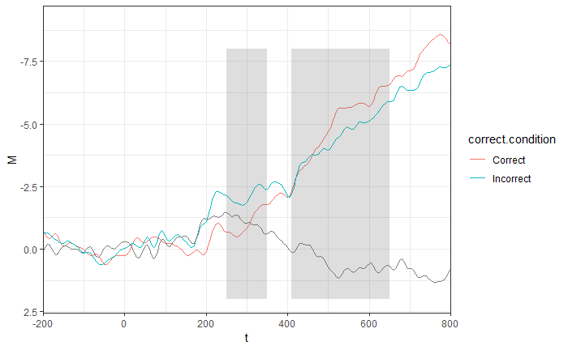

```r
n2.pp.correct.incorrect.plot.data <- n2.pp.correct.incorrect %>%
  group_by(correct.condition, t) %>%
  summarize(M = mean(voltage))
n2.pp.correct.incorrect.difference.wave.plot.data <- n2.pp.correct.incorrect.difference.wave %>%
  group_by(t) %>%
  summarize(M = mean(difference.wave))
ggplot(n2.pp.correct.incorrect.plot.data, aes(x=t,y=M,color=correct.condition))+
  geom_line()+
  geom_line(data=n2.pp.correct.incorrect.difference.wave.plot.data, aes(color=NA))+
  scale_y_reverse()+
  scale_x_continuous(limits = c(-200,800), expand=c(0,0))+
  annotate("rect", xmin=250,xmax=350,ymin=-8,ymax=2, alpha=0.2)+
  annotate("rect", xmin=410,xmax=650,ymin=-8,ymax=2, alpha=0.2)+
  theme_bw()
```

### Distractor and Target P3b

```r
p3b.correct.incorrect <- eeg.data.correct.incorrect %>%
  filter(electrode %in% c(54,55,79,78,61,62))
p3b.correct.incorrect.difference.wave <- p3b.correct.incorrect %>%
  spread(correct.condition, voltage) %>%
  mutate(difference.wave = Incorrect - Correct) %>%
  select(-Correct, -Incorrect)
```

Time window 400-550ms. Is difference wave significantly greater than 0?

[output not shown]

Time window 635-995ms. Is difference wave significantly less than 0?

[output not shown]

Plot

```r
p3b.correct.incorrect.plot.data <- p3b.correct.incorrect %>%
  group_by(correct.condition, t) %>%
  summarize(M = mean(voltage))
p3b.correct.incorrect.difference.wave.plot.data <- p3b.correct.incorrect.difference.wave %>%
  group_by(t) %>%
  summarize(M = mean(difference.wave))
```

[figure not shown]